# Lec05_exercise

shuna

1/26/2022

### **Key Components**

Every ggplot2 plot has three key components:

1. **data**
2. A set of **aesthetic mappings** between variables in the data and visual properties, and
3. At least one layer which describes how to render each observation. Layers are suually created with a **geom** funtion.

Here’s a sample example:

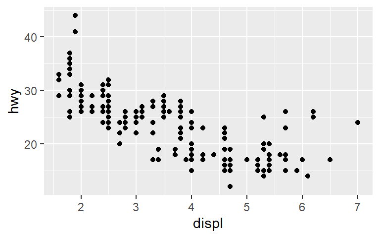

test

```r
ggplot(mpg, aes(x = displ, y = hwy))+
  geom_point()
```

This produces a scatterplot defined by:

1. Data: `mpg`
2. Aesthetic mapping: engine size mapped to `x` position, fuel economy to y position.
3. Layer: points

Pay attention to the structure of this function call: data and aesthetic mappings are supplied in `ggplot()`, then layers are added in with `+`. This is an important pattern, and as you learn more about ggplot2 you’ll construct increasingly sophisticated plots by adding on more types of components.

Almost every plot maps a variable to `x` and `y`, so naming these aesthetics is tedious, so the first two unnamed arguments to `aes()` will be mapped to `x` and `y`. This mean that the following code is identical to the example above:

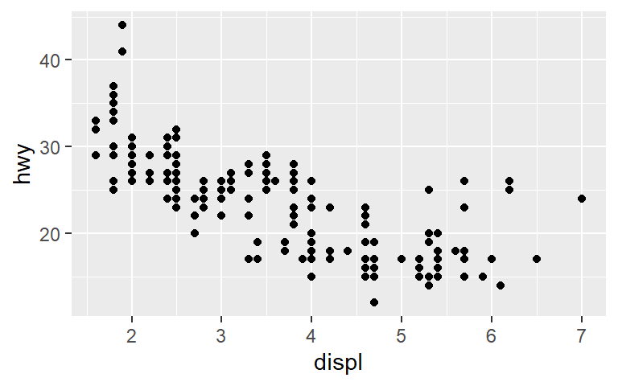

```r
ggplot(mpg, aes(displ, hwy))+
  geom_point()
```

I’ll stick to that style throughout the book, so don’t forget that the first two arguments to `aes()` are `x` and `y`. Note that I’ve put each command on a new line. I recommend doing this in your own code, so it’s easy to scan a plot specification and see exactly what’s there. In this chapter, I’ll sometimes use just one line per plot, because it makes it easier to see the differences between plot variations.

The plot shows a strong correlation: as the engine size gets bigger, the fuel economy gets worse. There are also some interesting outliers: some cars with large engines get higher fuel economy than average. What sort of cars do you think they are?